# This is just here so you can preview the styling on your local machine

[output not shown]

Each record is described by 12 fields

The following fields can be divided up for each record:

**activity_id:** unique identifier for each activity

**classification:** describes the type

**end_date:** date when activity is planned to conclude

**location:** physical address

**notes:** additional information

**source_id:** identifier for source

**start_date:** activity is planned to start

**status:** stage of completion or approval

**geometry:** geospatial data representing shape, location of activity (polygons)

**small_area:** smaller geographic area/ specific location details

**json_geometry:** geospatial data JSON format (geometry)

**geo_point_2d:** latitude & longitude geospatial data for pinpointing exact location

*refer to meta data for information on classification and notes*

```python
#View info of data
activities.info()
```

```
<class 'pandas.core.frame.DataFrame'>
RangeIndex: 605 entries, 0 to 604
Data columns (total 12 columns):
 #   Column          Non-Null Count  Dtype
---  ------          --------------  -----
 0   activity_id     605 non-null    object
 1   classification  605 non-null    object
 2   end_date        605 non-null    object
 3   location        603 non-null    object
 4   notes           500 non-null    object
 5   source_id       605 non-null    object
 6   start_date      605 non-null    object
 7   status          605 non-null    object
 8   geometry        605 non-null    object
 9   small_area      605 non-null    object
 10  json_geometry   0 non-null      object
 11  geo_point_2d    605 non-null    object
dtypes: object(12)
memory usage: 56.8+ KB
```

```python
# Check missing values for dataset
missing_values = activities.isnull().sum()
missing_values # Number of missing values in each column
```

```
activity_id         0
classification      0
end_date            0
location            2
notes             105
source_id           0
start_date          0
status              0
geometry            0
small_area          0
json_geometry     605
geo_point_2d        0
dtype: int64
```

```python
# Check missing values for dataset
# Find missing values in each column
missing_values = activities.isnull().sum()

# Corrected column names
column_name_notes = 'notes'
column_name_location = 'location'
column_name_json_geometry = 'json_geometry'

# Calculate the percentage of missing values
percentage_missing_notes = (missing_values[column_name_notes] / len(activities)) * 100
percentage_missing_location = (missing_values[column_name_location] / len(activities)) * 100
percentage_missing_json_geometry = (missing_values[column_name_json_geometry] / len(activities)) * 100

# Print the results
print(f"Percentage of missing values for '{column_name_notes}': {percentage_missing_notes:.2f}%")
print(f"Percentage of missing values for '{column_name_location}': {percentage_missing_location:.2f}%")
print(f"Percentage of missing values for '{column_name_json_geometry}': {percentage_missing_json_geometry:.2f}%")
```

```
Percentage of missing values for 'notes': 17.36%
Percentage of missing values for 'location': 0.33%
Percentage of missing values for 'json_geometry': 100.00%
```

```python
# Find missing notes
missing_notes_completed = activities[activities['notes'].isnull()]
missing_notes_completed
```

|  | activity_id | classification | end_date | location | notes | source_id | start_date | status | geometry | small_area | json_geometry | geo_point_2d |
| --- | --- | --- | --- | --- | --- | --- | --- | --- | --- | --- | --- | --- |
| 43 | P-355-4031-4031-9-Warning-200820180000-0307202... | Event | 2022-07-03 | Flagstaff Gardens: FG - Lawn 12 | None | BP355 | 2018-08-20 | WARNING | MULTIPOLYGON (((144.95501283438648 -37.8114374... | West Melbourne (Residential) | None | {"lon": 144.95488166212928, "lat": -37.8117943... |
| 44 | RP-59093-193956-20114-REM-Confirmed-1405202200... | Reserved Parking | 2022-05-14 | Collins Street between Elizabeth Street and Qu... | None | 33102 | 2022-05-14 | CONFIRMED | MULTIPOLYGON (((144.9620098149816 -37.81703725... | Melbourne (CBD) | None | {"lon": 144.96288709385632, "lat": -37.8166874... |
| 45 | RP-59107-194065-21975-BUS-Confirmed-1705202200... | Reserved Parking | 2022-05-17 | Jolimont Street between Jolimont Terrace and C... | None | 33116 | 2022-05-17 | CONFIRMED | MULTIPOLYGON (((144.9812715598986 -37.81868687... | East Melbourne | None | {"lon": 144.98137650338356, "lat": -37.8186069... |
| 46 | RP-59031-193435-20009-COU-Confirmed-1905202200... | Reserved Parking | 2022-05-19 | Lonsdale Street between Elizabeth Street and Q... | None | 33040 | 2022-05-19 | CONFIRMED | MULTIPOLYGON (((144.9601588020901 -37.81297584... | Melbourne (CBD) | None | {"lon": 144.96102928097045, "lat": -37.8126279... |
| 47 | RP-59031-193433-20009-COU-Confirmed-1705202200... | Reserved Parking | 2022-05-17 | Lonsdale Street between Elizabeth Street and Q... | None | 33040 | 2022-05-17 | CONFIRMED | MULTIPOLYGON (((144.9601588020901 -37.81297584... | Melbourne (CBD) | None | {"lon": 144.96102928097045, "lat": -37.8126279... |
| ... | ... | ... | ... | ... | ... | ... | ... | ... | ... | ... | ... | ... |
| 600 | P-6954-4055-4055-9-Provisional-240720220000-24... | Public Event | 2022-07-24 | Flinders Street: FS - Between Market St & Will... | None | BP6954 | 2022-07-24 | PROVISIONAL | MULTIPOLYGON (((144.960283790825 -37.819687064... | Melbourne (CBD) | None | {"lon": 144.96055676100832, "lat": -37.8194350... |
| 601 | RP-59031-193430-20009-COU-Confirmed-1405202200... | Reserved Parking | 2022-05-14 | Lonsdale Street between Elizabeth Street and Q... | None | 33040 | 2022-05-14 | CONFIRMED | MULTIPOLYGON (((144.9601588020901 -37.81297584... | Melbourne (CBD) | None | {"lon": 144.96102928097045, "lat": -37.8126279... |
| 602 | RP-59102-194038-21553-BUS-Confirmed-2605202200... | Reserved Parking | 2022-05-26 | Nicholson Street between Spring Street and Alb... | None | 33111 | 2022-05-26 | CONFIRMED | MULTIPOLYGON (((144.97318588585946 -37.8100440... | East Melbourne | None | {"lon": 144.97310878139405, "lat": -37.8100300... |
| 603 | P-336-4183-4183-9-Warning-280320180000-2803202... | Event | 2028-03-28 | Other Park Locations: OTH - Darling Square | None | BP336 | 2018-03-28 | WARNING | MULTIPOLYGON (((144.98962811546195 -37.8124083... | East Melbourne | None | {"lon": 144.98909705782177, "lat": -37.8128124... |
| 604 | P-7743-4209-4209-5-Provisional Multiple-221220... | Event | 2022-06-30 | Royal Park: RP - Lawn 7 | None | BP7743 | 2021-12-22 | PROVISIONAL MULTIPLE | MULTIPOLYGON (((144.9462924035227 -37.78631286... | Parkville | None | {"lon": 144.94689733286336, "lat": -37.7878634... |

105 rows × 12 columns

```python
#Replace "-" with NaN
activities['notes'].replace('-', float('nan'), inplace=True)
```

```python
# Find missing location
missing_location_completed = activities[activities['location'].isnull()]
missing_location_completed
```

|  | activity_id | classification | end_date | location | notes | source_id | start_date | status | geometry | small_area | json_geometry | geo_point_2d |
| --- | --- | --- | --- | --- | --- | --- | --- | --- | --- | --- | --- | --- |
| 427 | WO-721357-1438514-1438514-61-Closed-1001202200... | Traffic Management | 2022-06-30 | None | NaN | 721357 | 2022-01-10 | CONFIRMED | MULTIPOLYGON (((144.96622213919196 -37.8133736... | Melbourne (CBD) | None | {"lon": 144.96615899198162, "lat": -37.8133628... |
| 445 | WO-728357-1438751-1438751-61-Closed-0101202200... | Traffic Management | 2022-06-30 | None | NaN | 728357 | 2022-01-01 | CONFIRMED | MULTIPOLYGON (((144.96254632921952 -37.8067091... | Melbourne (CBD) | None | {"lon": 144.96216132334592, "lat": -37.8065740... |

```python
# Fill missing values in location
activities['location'].replace('None', float('nan'), inplace=True)
```

```python
# Find missing json_geometry
missing_json_geometry_completed = activities[activities['json_geometry'].isnull()]
missing_json_geometry_completed
```

|  | activity_id | classification | end_date | location | notes | source_id | start_date | status | geometry | small_area | json_geometry | geo_point_2d |
| --- | --- | --- | --- | --- | --- | --- | --- | --- | --- | --- | --- | --- |
| 0 | SS-1112882-0-104568-ESP-Referred to ESG-240520... | Structures | 2022-06-20 | 3B Haines Street\rNORTH MELBOURNE VIC 3051 | Space Occupancy on Footpath | ESP-2022-171 | 2022-05-24 | PROPOSED | MULTIPOLYGON (((144.95001002561838 -37.7992336... | North Melbourne | None | {"lon": 144.94995352698322, "lat": -37.7991232... |
| 1 | SS-1078568-0-103627-EGA-Permit Issued-07082021... | Structures | 2022-08-08 | 104-110 Exhibition Street\rMELBOURNE VIC 3000 | Gantry | EGA-2021-61 | 2021-08-07 | CONFIRMED | MULTIPOLYGON (((144.97152275796896 -37.8131325... | Melbourne (CBD) | None | {"lon": 144.97136205426054, "lat": -37.8130886... |
| 2 | WO-721357-1445540-1445540-61-Closed-1001202200... | Traffic Management | 2022-06-30 | Russell Street between Collins Street and Litt... | NaN | 721357 | 2022-01-10 | CONFIRMED | MULTIPOLYGON (((144.96871424384977 -37.8141450... | Melbourne (CBD) | None | {"lon": 144.9687268410667, "lat": -37.81412962... |
| 3 | SS-1079739-0-593729-EGA-Permit Issued-18082021... | Structures | 2022-08-17 | 60 Waterfront Way\rDOCKLANDS VIC 3008 | Gantry | EGA-2021-65 | 2021-08-18 | CONFIRMED | MULTIPOLYGON (((144.9387065073275 -37.81225537... | Docklands | None | {"lon": 144.93941705204935, "lat": -37.8121959... |
| 4 | SS-1114327-0-101142-EGA-Permit Issued-01052022... | Structures | 2022-05-31 | 309-325 Bourke Street\rMELBOURNE VIC 3000 | Gantry | EGA-2021-59/5 | 2022-05-01 | CONFIRMED | MULTIPOLYGON (((144.96455690948278 -37.8139786... | Melbourne (CBD) | None | {"lon": 144.96453826103547, "lat": -37.8144409... |
| ... | ... | ... | ... | ... | ... | ... | ... | ... | ... | ... | ... | ... |
| 600 | P-6954-4055-4055-9-Provisional-240720220000-24... | Public Event | 2022-07-24 | Flinders Street: FS - Between Market St & Will... | None | BP6954 | 2022-07-24 | PROVISIONAL | MULTIPOLYGON (((144.960283790825 -37.819687064... | Melbourne (CBD) | None | {"lon": 144.96055676100832, "lat": -37.8194350... |
| 601 | RP-59031-193430-20009-COU-Confirmed-1405202200... | Reserved Parking | 2022-05-14 | Lonsdale Street between Elizabeth Street and Q... | None | 33040 | 2022-05-14 | CONFIRMED | MULTIPOLYGON (((144.9601588020901 -37.81297584... | Melbourne (CBD) | None | {"lon": 144.96102928097045, "lat": -37.8126279... |
| 602 | RP-59102-194038-21553-BUS-Confirmed-2605202200... | Reserved Parking | 2022-05-26 | Nicholson Street between Spring Street and Alb... | None | 33111 | 2022-05-26 | CONFIRMED | MULTIPOLYGON (((144.97318588585946 -37.8100440... | East Melbourne | None | {"lon": 144.97310878139405, "lat": -37.8100300... |
| 603 | P-336-4183-4183-9-Warning-280320180000-2803202... | Event | 2028-03-28 | Other Park Locations: OTH - Darling Square | None | BP336 | 2018-03-28 | WARNING | MULTIPOLYGON (((144.98962811546195 -37.8124083... | East Melbourne | None | {"lon": 144.98909705782177, "lat": -37.8128124... |
| 604 | P-7743-4209-4209-5-Provisional Multiple-221220... | Event | 2022-06-30 | Royal Park: RP - Lawn 7 | None | BP7743 | 2021-12-22 | PROVISIONAL MULTIPLE | MULTIPOLYGON (((144.9462924035227 -37.78631286... | Parkville | None | {"lon": 144.94689733286336, "lat": -37.7878634... |

605 rows × 12 columns

```python
# Fill missing values in json_geometry
activities['json_geometry'].replace('None', float('nan'), inplace=True)
```

```python
# Check number of unique elements and number of rows (shape/ data points)
unique_dev_keys_in_activities = activities['activity_id'].nunique()
print(f"Number of unique 'activity_id' values in activities: {unique_dev_keys_in_activities}")

total_data_in_activities = activities.shape[0]
print(f"Total number of elements in activities: {total_data_in_activities}")
```

```
Number of unique 'activity_id' values in activities: 605
Total number of elements in activities: 605
```

```python
# Check for duplicates
duplicates = activities.duplicated()

# Count the number of duplicates
num_duplicates = duplicates.sum()

# Display
duplicate_rows = activities[duplicates]
print("Number of duplicate rows:", num_duplicates)
print("Duplicate rows:")
print(duplicate_rows)
```

```
Number of duplicate rows: 0
Duplicate rows:
Empty DataFrame
Columns: [activity_id, classification, end_date, location, notes, source_id, start_date, status, geometry, small_area, json_geometry, geo_point_2d]
Index: []
```

```python
# Change error years
activities.at[335, 'end_date'] = '2021-11-19' #2921-11-19
activities.at[14, 'end_date'] = '2016-10-11' #2106-10-11
activities.at[144, 'end_date'] = '2016-10-11' #2106-10-11
activities.at[15, 'end_date'] = '2018-09-09' #2108-09-09
activities.at[193, 'end_date'] = '2018-09-09' #2108-09-09
```

##### Check data types

```python
activities.dtypes
```

```
activity_id       object
classification    object
end_date          object
location          object
notes             object
source_id         object
start_date        object
status            object
geometry          object
small_area        object
json_geometry     object
geo_point_2d      object
dtype: object
```

##### Convert Data Types

```python
# Convert the 'start_date' and 'end_date' columns to datetime
activities['start_date'] = pd.to_datetime(activities['start_date'])
activities['end_date'] = pd.to_datetime(activities['end_date'])
```

```python
# Print all unfinished cases
activities[activities['end_date'].dt.year > 2023]
```

|  | activity_id | classification | end_date | location | notes | source_id | start_date | status | geometry | small_area | json_geometry | geo_point_2d |
| --- | --- | --- | --- | --- | --- | --- | --- | --- | --- | --- | --- | --- |
| 118 | P-415-4179-4179-9-Warning-190820180300-3112202... | Event | 2025-12-31 | Other Park Locations: OTH - Batman Park | None | BP415 | 2018-08-19 | WARNING | MULTIPOLYGON (((144.9574466610408 -37.82169854... | Melbourne (CBD) | None | {"lon": 144.956675068557, "lat": -37.821825623... |
| 182 | P-213-4194-4194-9-Warning-140820181130-3007202... | Event | 2025-07-30 | Other Park Locations: OTH - University Square | None | BP213 | 2018-08-14 | WARNING | MULTIPOLYGON (((144.9609369585162 -37.80090532... | Carlton | None | {"lon": 144.96036839250445, "lat": -37.8010372... |
| 537 | P-159-4117-4117-9-Warning-140820180530-3006202... | Event | 2025-06-30 | Laneway/Place/Alley: L/P/A - ACDC Lane/Duckboa... | None | BP159 | 2018-08-14 | WARNING | MULTIPOLYGON (((144.97084247990034 -37.8153816... | Melbourne (CBD) | None | {"lon": 144.97093628969864, "lat": -37.8156390... |
| 603 | P-336-4183-4183-9-Warning-280320180000-2803202... | Event | 2028-03-28 | Other Park Locations: OTH - Darling Square | None | BP336 | 2018-03-28 | WARNING | MULTIPOLYGON (((144.98962811546195 -37.8124083... | East Melbourne | None | {"lon": 144.98909705782177, "lat": -37.8128124... |

```python
# Remove unfinished cases to calculate duration

# Filter rows where start_year is less than or equal to 2023
activities = activities[activities['end_date'].dt.year <= 2023]

# Calculate duration
activities['duration'] = (activities['end_date'] - activities['start_date']).dt.days
```

```python
# Replace incorrectly 'status'
activities['status'].replace({'Confirmed':'CONFIRMED'}, inplace=True)
activities['status'].unique()
```

```
array(['PROPOSED', 'CONFIRMED', 'WARNING', 'PROVISIONAL MULTIPLE',
       'REINSTATEMENT', 'PROVISIONAL'], dtype=object)
```

```python
# Create month_year column based on start_date
activities['month_year'] = activities['start_date'].dt.to_period('M')
```

```python
# Check overall data types
activities.dtypes
```

```
activity_id               object
classification            object
end_date          datetime64[ns]
location                  object
notes                     object
source_id                 object
start_date        datetime64[ns]
status                    object
geometry                  object
small_area                object
json_geometry             object
geo_point_2d              object
duration                   int64
month_year             period[M]
dtype: object
```

##### Split to Longitude and Latitude

```python
# Find latitude & longitude from geo_point_2d
# Create separate columns for both

# Function to extract longitude and latitude
def extract_lon_lat(geo_point):
    geo_data = json.loads(geo_point)
    return geo_data['lon'], geo_data['lat']

# Apply the function to the DataFrame
activities[['longitude', 'latitude']] = activities['geo_point_2d'].apply(extract_lon_lat).apply(pd.Series)
activities = activities.drop('geo_point_2d', axis=1)

activities.head()
```

|  | activity_id | classification | end_date | location | notes | source_id | start_date | status | geometry | small_area | json_geometry | duration | month_year | longitude | latitude |
| --- | --- | --- | --- | --- | --- | --- | --- | --- | --- | --- | --- | --- | --- | --- | --- |
| 0 | SS-1112882-0-104568-ESP-Referred to ESG-240520... | Structures | 2022-06-20 | 3B Haines Street\rNORTH MELBOURNE VIC 3051 | Space Occupancy on Footpath | ESP-2022-171 | 2022-05-24 | PROPOSED | MULTIPOLYGON (((144.95001002561838 -37.7992336... | North Melbourne | None | 27 | 2022-05 | 144.949954 | -37.799123 |
| 1 | SS-1078568-0-103627-EGA-Permit Issued-07082021... | Structures | 2022-08-08 | 104-110 Exhibition Street\rMELBOURNE VIC 3000 | Gantry | EGA-2021-61 | 2021-08-07 | CONFIRMED | MULTIPOLYGON (((144.97152275796896 -37.8131325... | Melbourne (CBD) | None | 366 | 2021-08 | 144.971362 | -37.813089 |
| 2 | WO-721357-1445540-1445540-61-Closed-1001202200... | Traffic Management | 2022-06-30 | Russell Street between Collins Street and Litt... | NaN | 721357 | 2022-01-10 | CONFIRMED | MULTIPOLYGON (((144.96871424384977 -37.8141450... | Melbourne (CBD) | None | 171 | 2022-01 | 144.968727 | -37.814130 |
| 3 | SS-1079739-0-593729-EGA-Permit Issued-18082021... | Structures | 2022-08-17 | 60 Waterfront Way\rDOCKLANDS VIC 3008 | Gantry | EGA-2021-65 | 2021-08-18 | CONFIRMED | MULTIPOLYGON (((144.9387065073275 -37.81225537... | Docklands | None | 364 | 2021-08 | 144.939417 | -37.812196 |
| 4 | SS-1114327-0-101142-EGA-Permit Issued-01052022... | Structures | 2022-05-31 | 309-325 Bourke Street\rMELBOURNE VIC 3000 | Gantry | EGA-2021-59/5 | 2022-05-01 | CONFIRMED | MULTIPOLYGON (((144.96455690948278 -37.8139786... | Melbourne (CBD) | None | 30 | 2022-05 | 144.964538 | -37.814441 |

##### Duration

```python
# Calculate the duration in days
activities['duration'] = (activities['end_date'] - activities['start_date']).dt.days

activities.head()
```

|  | activity_id | classification | end_date | location | notes | source_id | start_date | status | geometry | small_area | json_geometry | duration | month_year | longitude | latitude |
| --- | --- | --- | --- | --- | --- | --- | --- | --- | --- | --- | --- | --- | --- | --- | --- |
| 0 | SS-1112882-0-104568-ESP-Referred to ESG-240520... | Structures | 2022-06-20 | 3B Haines Street\rNORTH MELBOURNE VIC 3051 | Space Occupancy on Footpath | ESP-2022-171 | 2022-05-24 | PROPOSED | MULTIPOLYGON (((144.95001002561838 -37.7992336... | North Melbourne | None | 27 | 2022-05 | 144.949954 | -37.799123 |
| 1 | SS-1078568-0-103627-EGA-Permit Issued-07082021... | Structures | 2022-08-08 | 104-110 Exhibition Street\rMELBOURNE VIC 3000 | Gantry | EGA-2021-61 | 2021-08-07 | CONFIRMED | MULTIPOLYGON (((144.97152275796896 -37.8131325... | Melbourne (CBD) | None | 366 | 2021-08 | 144.971362 | -37.813089 |
| 2 | WO-721357-1445540-1445540-61-Closed-1001202200... | Traffic Management | 2022-06-30 | Russell Street between Collins Street and Litt... | NaN | 721357 | 2022-01-10 | CONFIRMED | MULTIPOLYGON (((144.96871424384977 -37.8141450... | Melbourne (CBD) | None | 171 | 2022-01 | 144.968727 | -37.814130 |
| 3 | SS-1079739-0-593729-EGA-Permit Issued-18082021... | Structures | 2022-08-17 | 60 Waterfront Way\rDOCKLANDS VIC 3008 | Gantry | EGA-2021-65 | 2021-08-18 | CONFIRMED | MULTIPOLYGON (((144.9387065073275 -37.81225537... | Docklands | None | 364 | 2021-08 | 144.939417 | -37.812196 |
| 4 | SS-1114327-0-101142-EGA-Permit Issued-01052022... | Structures | 2022-05-31 | 309-325 Bourke Street\rMELBOURNE VIC 3000 | Gantry | EGA-2021-59/5 | 2022-05-01 | CONFIRMED | MULTIPOLYGON (((144.96455690948278 -37.8139786... | Melbourne (CBD) | None | 30 | 2022-05 | 144.964538 | -37.814441 |

##### Removed /r from location

```python
# Remove /r (location)
def replace_r_with_space(text):
    if text is not None and pd.notna(text):
        return text.replace("\r", " ")
    else:
        return text

activities['location'] = activities['location'].apply(replace_r_with_space)
```

```python
activities.head()
```

|  | activity_id | classification | end_date | location | notes | source_id | start_date | status | geometry | small_area | json_geometry | duration | month_year | longitude | latitude |
| --- | --- | --- | --- | --- | --- | --- | --- | --- | --- | --- | --- | --- | --- | --- | --- |
| 0 | SS-1112882-0-104568-ESP-Referred to ESG-240520... | Structures | 2022-06-20 | 3B Haines Street NORTH MELBOURNE VIC 3051 | Space Occupancy on Footpath | ESP-2022-171 | 2022-05-24 | PROPOSED | MULTIPOLYGON (((144.95001002561838 -37.7992336... | North Melbourne | None | 27 | 2022-05 | 144.949954 | -37.799123 |
| 1 | SS-1078568-0-103627-EGA-Permit Issued-07082021... | Structures | 2022-08-08 | 104-110 Exhibition Street MELBOURNE VIC 3000 | Gantry | EGA-2021-61 | 2021-08-07 | CONFIRMED | MULTIPOLYGON (((144.97152275796896 -37.8131325... | Melbourne (CBD) | None | 366 | 2021-08 | 144.971362 | -37.813089 |
| 2 | WO-721357-1445540-1445540-61-Closed-1001202200... | Traffic Management | 2022-06-30 | Russell Street between Collins Street and Litt... | NaN | 721357 | 2022-01-10 | CONFIRMED | MULTIPOLYGON (((144.96871424384977 -37.8141450... | Melbourne (CBD) | None | 171 | 2022-01 | 144.968727 | -37.814130 |
| 3 | SS-1079739-0-593729-EGA-Permit Issued-18082021... | Structures | 2022-08-17 | 60 Waterfront Way DOCKLANDS VIC 3008 | Gantry | EGA-2021-65 | 2021-08-18 | CONFIRMED | MULTIPOLYGON (((144.9387065073275 -37.81225537... | Docklands | None | 364 | 2021-08 | 144.939417 | -37.812196 |
| 4 | SS-1114327-0-101142-EGA-Permit Issued-01052022... | Structures | 2022-05-31 | 309-325 Bourke Street MELBOURNE VIC 3000 | Gantry | EGA-2021-59/5 | 2022-05-01 | CONFIRMED | MULTIPOLYGON (((144.96455690948278 -37.8139786... | Melbourne (CBD) | None | 30 | 2022-05 | 144.964538 | -37.814441 |

```python
#Define attributes
activities_reduced = activities[['classification', 'end_date', 'notes', 'start_date', 'status', 'small_area']]

activities_reduced.head()
```

|  | classification | end_date | notes | start_date | status | small_area |
| --- | --- | --- | --- | --- | --- | --- |
| 0 | Structures | 2022-06-20 | Space Occupancy on Footpath | 2022-05-24 | PROPOSED | North Melbourne |
| 1 | Structures | 2022-08-08 | Gantry | 2021-08-07 | CONFIRMED | Melbourne (CBD) |
| 2 | Traffic Management | 2022-06-30 | NaN | 2022-01-10 | CONFIRMED | Melbourne (CBD) |
| 3 | Structures | 2022-08-17 | Gantry | 2021-08-18 | CONFIRMED | Docklands |
| 4 | Structures | 2022-05-31 | Gantry | 2022-05-01 | CONFIRMED | Melbourne (CBD) |

##### Define attributes required

**classification:** describes the type

**end_date:** date when activity is planned to conclude

**notes:** additional information

**start_date:** activity is planned to start

**status:** stage of completion or approval

**geo_point_2d:** latitude & longitude geospatial data for pinpointing exact location

**small_area:** smaller geographic area/ specific location details

```python
# Check data types
activities_reduced.dtypes
```

```
classification            object
end_date          datetime64[ns]
notes                     object
start_date        datetime64[ns]
status                    object
small_area                object
dtype: object
```

#### Dataset 2: Development Activity Model Footprints

- Dataset Identifier: development-activity-model-footprints
- Source data updated: Monthly

[Dataset Link](https://data.melbourne.vic.gov.au/explore/dataset/development-activity-model-footprints/table/)

**Summary:** This dataset contains spatial information about development activity located within the City of Melbourne municipal area. Developments may have one of four statuses. Applied, Approved and Under Construction, and Complete.

Note: *The development polygons are representational only and are not intended for analytical or comparative purposes. The polygons are simplified polygons of an indicative floor plate for the podium (if relevant) and tower. The height data is an approximation of the height of the building and does not show the architectural features of the buildings.*

Note: *All developments that were either applied, approved, under construction or completed between November 2015 and May 2016 have now been formatted such that each row of the data represents an individual building. If a single building consists of one podium and two towers this development is split into two rows; one for the podium and a tower, and another for the additional tower.*

```python
# # Use cell for Google Drive
# # Save/ locate saved code to drive

# # CSV file path
# csv_file_path = '/content/drive/MyDrive/planned_works/datasets/footprints.csv'

# # Check file
# if os.path.exists(csv_file_path):
#     # Load CSV
#     footprints = pd.read_csv(csv_file_path)
#     print("Data loaded from CSV")
# else:
#     # Fetch data
#     SENSOR_DATASET = 'development-activity-model-footprints'
#     footprints = fetch_data(BASE_URL, SENSOR_DATASET, API_KEY)
#     print("Data fetched from API key")

#     # Check if the DataFrame exists and is not empty
#     if not footprints.empty:
#         # Save CSV file
#         footprints.to_csv(csv_file_path, index=False)
#         print('Data saved to:', csv_file_path)
#     else:
#         # Not able to save data
#         print('Unable to save data. The DataFrame is empty or does not exist.')

#     # Check if the file was created
#     if os.path.exists(csv_file_path):
#         print('File exists.')
#     else:
#         print('File does not exist. There was an issue saving the data.')

# footprints.head() # View data
```

```python
# # Use cell for Google Drive
# # Save dataframe
# # Check file
# csv_file_path = '/content/drive/MyDrive/planned_works/datasets/footprints.csv'
# # Check if the DataFrame exists and is not empty
# if not footprints.empty:
#     # Save CSV file
#     footprints.to_csv(csv_file_path, index=False)
#     print('Data saved to:', csv_file_path)
# else:
#     # Not able to save data
#     print('Unable to save data. The DataFrame is empty or does not exist.')

# # Check if the file was created
# if os.path.exists(csv_file_path):
#     print('File exists.')
# else:
#     print('File does not exist. There was an issue saving the data.')
```

```python
SENSOR_DATASET = 'development-activity-model-footprints'
footprints = fetch_data(BASE_URL, SENSOR_DATASET, API_KEY)
footprints.head()
```

|  | dev_key | status | permit_num | bldhgt_ahd | base_ahd | address | num_floors | land_use_1 | land_use_2 | land_use_3 | shape_type | geo_point_2d |
| --- | --- | --- | --- | --- | --- | --- | --- | --- | --- | --- | --- | --- |
| 0 | X001285 | APPROVED | TPM-2015-28 | 29.1 | 2.4 | 293-297 City Road SOUTHBANK VIC 3006 | 57 | Dwellings 365 | Car parks 149 | Office (sq.m) 817 | podium | {'lon': 144.95873612895497, 'lat': -37.8276191... |
| 1 | X000938 | COMPLETED | TP-2009-724/B | 103.8 | 0.6 | 248-254 City Road SOUTHBANK VIC 3006 | 32 | Dwellings 228 | Car parks 39 | Bike Spaces 107 | tower | {'lon': 144.9596754806277, 'lat': -37.82567372... |
| 2 | X000725 | COMPLETED | TP-2013-1006/A | 121.8 | 2.0 | 61-63 Haig Street SOUTHBANK VIC 3006 | 38 | Dwellings 163 | Car parks 104 | Bike Spaces 197 | tower | {'lon': 144.95680830559633, 'lat': -37.8277439... |
| 3 | X001289 | APPROVED | TPM-2015-18 | 146.3 | 1.3 | 93-119 Kavagh Street SOUTHBANK VIC 3006 | 37 | Office (sq.m) 49600 | Car parks 116 | None | tower | {'lon': 144.9627780910714, 'lat': -37.82583306... |
| 4 | X001292 | COMPLETED | TPM-2015-18 | 171.3 | 1.3 | 93-119 Kavagh Street SOUTHBANK VIC 3006 | 56 | Dwellings 437 | Office (sq.m) 657 | None | tower | {'lon': 144.9633671451759, 'lat': -37.82601856... |

The following fields can be divided up for each record:

**dev_key:** Development key, identifier for Development Activity Monitor entries.

**status:** Current status of the development. Under construction: The development is currently under construction. Approved: The development has town planning approval. Applied: The development has a town planning application which is yet to be approved. Complete: The development has been completed.

**shape_type:** Classification for footprint geometry type, categories are: podium: a an object which represents the basic podium shape of the development. tower_pod: a tower where a podium is also present for the same development. tower: a standalone tower. extension: a refurbishment/extension where the original building (footprint) is retained.

**permit_num:** Planning application number.

**bldhgt_ahd:** Ground level height (AHD).

**base_ahd:** Standard reference point for height measurements. Represent the height above 'Australian Height Datum'

**address:** Address of the development.

**num_floors:** Number of floors above ground. This field can also have NA values.

**land_use_1:** The quantity of the primary space use of the development.

**land_use_2:** The quantity of the secondary space use of the development.

**land_use_3:** The quantity of the tertiary space use of the development.

*refer to meta data for information on additional fields and descriptions*

##### Check missing values for dataset

```python
#View info of data
footprints.info()
```

```
<class 'pandas.core.frame.DataFrame'>
RangeIndex: 1258 entries, 0 to 1257
Data columns (total 12 columns):
 #   Column        Non-Null Count  Dtype
---  ------        --------------  -----
 0   dev_key       1258 non-null   object
 1   status        1258 non-null   object
 2   permit_num    1258 non-null   object
 3   bldhgt_ahd    1258 non-null   float64
 4   base_ahd      1258 non-null   float64
 5   address       1258 non-null   object
 6   num_floors    1258 non-null   int64
 7   land_use_1    1243 non-null   object
 8   land_use_2    1133 non-null   object
 9   land_use_3    950 non-null    object
 10  shape_type    1258 non-null   object
 11  geo_point_2d  1258 non-null   object
dtypes: float64(2), int64(1), object(9)
memory usage: 118.1+ KB
```

```python
# Check missing values for dataset
# Find missing values in each column
missing_values = footprints.isnull().sum()
missing_values # Number of missing values in each column
```

```
dev_key           0
status            0
permit_num        0
bldhgt_ahd        0
base_ahd          0
address           0
num_floors        0
land_use_1       15
land_use_2      125
land_use_3      308
shape_type        0
geo_point_2d      0
dtype: int64
```

```python
# Fill missing values in location
footprints['land_use_1'].replace('None', float('nan'), inplace=True)
footprints['land_use_2'].replace('None', float('nan'), inplace=True)
footprints['land_use_3'].replace('None', float('nan'), inplace=True)
```

```python
# Footprints: Check number of unique elements and number of rows (shape/ data points)
unique_dev_keys_in_footprints = footprints['dev_key'].nunique()
print(f"Number of unique 'development_key' values in footprints: {unique_dev_keys_in_footprints}")

total_data_in_footprints = footprints.shape[0]
print(f"Total number of elements in footprints: {total_data_in_footprints}")
```

```
Number of unique 'development_key' values in footprints: 741
Total number of elements in footprints: 1258
```

```python
# Find duplicates based on 'dev_key'
duplicates_dev_key = footprints[footprints.duplicated(subset='dev_key', keep=False)]

# Display rows with duplicate 'dev_key' values
print("Rows with duplicate 'dev_key' values:")
duplicates_dev_key

# Differences in the attributes may be causing the discrepancy in the counts
```

```
Rows with duplicate 'dev_key' values:
```

|  | dev_key | status | permit_num | bldhgt_ahd | base_ahd | address | num_floors | land_use_1 | land_use_2 | land_use_3 | shape_type | geo_point_2d |
| --- | --- | --- | --- | --- | --- | --- | --- | --- | --- | --- | --- | --- |
| 0 | X001285 | APPROVED | TPM-2015-28 | 29.1 | 2.4 | 293-297 City Road SOUTHBANK VIC 3006 | 57 | Dwellings 365 | Car parks 149 | Office (sq.m) 817 | podium | {'lon': 144.95873612895497, 'lat': -37.8276191... |
| 1 | X000938 | COMPLETED | TP-2009-724/B | 103.8 | 0.6 | 248-254 City Road SOUTHBANK VIC 3006 | 32 | Dwellings 228 | Car parks 39 | Bike Spaces 107 | tower | {'lon': 144.9596754806277, 'lat': -37.82567372... |
| 2 | X000725 | COMPLETED | TP-2013-1006/A | 121.8 | 2.0 | 61-63 Haig Street SOUTHBANK VIC 3006 | 38 | Dwellings 163 | Car parks 104 | Bike Spaces 197 | tower | {'lon': 144.95680830559633, 'lat': -37.8277439... |
| 3 | X001289 | APPROVED | TPM-2015-18 | 146.3 | 1.3 | 93-119 Kavagh Street SOUTHBANK VIC 3006 | 37 | Office (sq.m) 49600 | Car parks 116 | None | tower | {'lon': 144.9627780910714, 'lat': -37.82583306... |
| 5 | X000898 | APPROVED | TPM-2010-8 | 141.7 | 2.0 | 158-164 City Road SOUTHBANK VIC 3006 | 44 | Dwellings 449 | Car parks 275 | Retail (sq.m) 1640 | tower | {'lon': 144.96242684529625, 'lat': -37.8234173... |
| ... | ... | ... | ... | ... | ... | ... | ... | ... | ... | ... | ... | ... |
| 1250 | X0010006 | APPROVED | TPM-2016-5/B | 104.2 | 4.0 | 685-691 La Trobe Street DOCKLANDS VIC 3008 | 30 | Dwellings 328 | Recreation (sq.m) 2638 | Car parks 136 | tower | {'lon': 144.94630857340783, 'lat': -37.8150811... |
| 1251 | X0010010 | APPROVED | TPM-2015-30/D | 219.5 | 16.4 | 111-125 A'Beckett Street MELBOURNE VIC 3000 | 65 | Dwellings 655 | Childcare places 200 | Car parks 149 | tower | {'lon': 144.96022049617508, 'lat': -37.8097260... |
| 1252 | X0010402 | APPROVED | TPMR-2014-35/C | 82.4 | 2.4 | 7-23 Spencer Street DOCKLANDS VIC 3008 | 21 | Office (sq.m) 43816 | Retail (sq.m) 1136 | Car parks 55 | tower | {'lon': 144.9548747945651, 'lat': -37.82217903... |
| 1256 | X0010619 | APPROVED | TPMR-2019-20/A | 165.7 | 15.2 | 600 Lonsdale Street, Melbourne, 3000 | 41 | Office (sq.m) 16559 | Hotel rooms 288 | Retail (sq.m) 1080 | tower | {'lon': 144.95433762858565, 'lat': -37.8141756... |
| 1257 | X0005800 | APPROVED | TP-2019-22 | 35.2 | 22.5 | 501-509 King Street, West Melbourne, 3003 | 8 | Car parks 145 | Hospital (sq.m) 629 | Bike Spaces 138 | podium | {'lon': 144.9509682181188, 'lat': -37.80793849... |

947 rows × 12 columns

```python
# Remove duplicates
unique_footprints = footprints.drop_duplicates(subset='dev_key', keep='first')

# Check number of unique elements and number of rows after keeping only unique 'development_key' values
unique_dev_keys_in_footprints = unique_footprints['dev_key'].nunique()
print(f"Number of unique 'development_key' values in footprints: {unique_dev_keys_in_footprints}")

total_data_in_unique_footprints = unique_footprints.shape[0]
print(f"Total number of elements in footprints after keeping only unique 'development_key' values: {total_data_in_unique_footprints}")
```

```
Number of unique 'development_key' values in footprints: 741
Total number of elements in footprints after keeping only unique 'development_key' values: 741
```

##### Processing land_use

```python
# Remove numbers from the 'land_use'
footprints['land_use_1'] = footprints['land_use_1'].str.replace('\d+', '', regex=True)
footprints['land_use_2'] = footprints['land_use_2'].str.replace('\d+', '', regex=True)
footprints['land_use_3'] = footprints['land_use_3'].str.replace('\d+', '', regex=True)
```

```python
# Remove (sq.m) from the 'land_use'
footprints['land_use_1'] = footprints['land_use_1'].str.replace('\(sq\.m\)', '', regex=True).str.strip()
footprints['land_use_2'] = footprints['land_use_2'].str.replace('\(sq\.m\)', '', regex=True).str.strip()
footprints['land_use_3'] = footprints['land_use_3'].str.replace('\(sq\.m\)', '', regex=True).str.strip()
```

```python
# Convert the values to numeric format
footprints['bldhgt_ahd'] = pd.to_numeric(footprints['bldhgt_ahd'], errors='coerce').astype(float)
```

```python
# Create year_started based on permit_num
footprints['year_started'] = footprints['permit_num'].str.extract(r'-(\d+)-')
```

```python
footprints.info()
```

```
<class 'pandas.core.frame.DataFrame'>
RangeIndex: 1258 entries, 0 to 1257
Data columns (total 13 columns):
 #   Column        Non-Null Count  Dtype
---  ------        --------------  -----
 0   dev_key       1258 non-null   object
 1   status        1258 non-null   object
 2   permit_num    1258 non-null   object
 3   bldhgt_ahd    1258 non-null   float64
 4   base_ahd      1258 non-null   float64
 5   address       1258 non-null   object
 6   num_floors    1258 non-null   int64
 7   land_use_1    1243 non-null   object
 8   land_use_2    1133 non-null   object
 9   land_use_3    950 non-null    object
 10  shape_type    1258 non-null   object
 11  geo_point_2d  1258 non-null   object
 12  year_started  1248 non-null   object
dtypes: float64(2), int64(1), object(10)
memory usage: 127.9+ KB
```

##### Split to Longitude and Latitude

```python
# Create longitude and latitude columns
footprints[['longitude', 'latitude']] = footprints['geo_point_2d'].apply(lambda x: pd.Series([x['lon'], x['lat']]))
```

##### Define attributes required

**dev_key:** Development key, identifier for Development Activity Monitor entries.

**status:** Current status of the development. Under construction: The development is currently under construction. Approved: The development has town planning approval. Applied: The development has a town planning application which is yet to be approved. Complete: The development has been completed.

**bldhgt_ahd:** Ground level height (AHD).

**base_ahd:** Standard reference point for height measurements. Represent the height above 'Australian Height Datum'

**shape_type:** Classification for footprint geometry type, categories are: podium: a an object which represents the basic podium shape of the development. tower_pod: a tower where a podium is also present for the same development. tower: a standalone tower. extension: a refurbishment/extension where the original building (footprint) is retained.

**land_use_1:** The quantity of the primary space use of the development.

**land_use_2:** The quantity of the secondary space use of the development.

**land_use_3:** The quantity of the tertiary space use of the development.

*refer to meta data for information on additional fields and descriptions*

```python
footprints = footprints[['dev_key', 'status', 'bldhgt_ahd', 'base_ahd', 'num_floors', 'land_use_1', 'land_use_2',
                         'land_use_3', 'shape_type', 'longitude', 'latitude']]
footprints.head()
```

|  | dev_key | status | bldhgt_ahd | base_ahd | num_floors | land_use_1 | land_use_2 | land_use_3 | shape_type | longitude | latitude |
| --- | --- | --- | --- | --- | --- | --- | --- | --- | --- | --- | --- |
| 0 | X001285 | APPROVED | 29.1 | 2.4 | 57 | Dwellings | Car parks | Office | podium | 144.958736 | -37.827619 |
| 1 | X000938 | COMPLETED | 103.8 | 0.6 | 32 | Dwellings | Car parks | Bike Spaces | tower | 144.959675 | -37.825674 |
| 2 | X000725 | COMPLETED | 121.8 | 2.0 | 38 | Dwellings | Car parks | Bike Spaces | tower | 144.956808 | -37.827744 |
| 3 | X001289 | APPROVED | 146.3 | 1.3 | 37 | Office | Car parks | None | tower | 144.962778 | -37.825833 |
| 4 | X001292 | COMPLETED | 171.3 | 1.3 | 56 | Dwellings | Office | None | tower | 144.963367 | -37.826019 |

```python
footprints.info()
```

```
<class 'pandas.core.frame.DataFrame'>
RangeIndex: 1258 entries, 0 to 1257
Data columns (total 11 columns):
 #   Column      Non-Null Count  Dtype
---  ------      --------------  -----
 0   dev_key     1258 non-null   object
 1   status      1258 non-null   object
 2   bldhgt_ahd  1258 non-null   float64
 3   base_ahd    1258 non-null   float64
 4   num_floors  1258 non-null   int64
 5   land_use_1  1243 non-null   object
 6   land_use_2  1133 non-null   object
 7   land_use_3  950 non-null    object
 8   shape_type  1258 non-null   object
 9   longitude   1258 non-null   float64
 10  latitude    1258 non-null   float64
dtypes: float64(4), int64(1), object(6)
memory usage: 108.2+ KB
```

```python
# convert the values to numeric format
footprints['bldhgt_ahd'] = pd.to_numeric(footprints['bldhgt_ahd'], errors='coerce').astype(float)
footprints.info()
```

```
<class 'pandas.core.frame.DataFrame'>
RangeIndex: 1258 entries, 0 to 1257
Data columns (total 11 columns):
 #   Column      Non-Null Count  Dtype
---  ------      --------------  -----
 0   dev_key     1258 non-null   object
 1   status      1258 non-null   object
 2   bldhgt_ahd  1258 non-null   float64
 3   base_ahd    1258 non-null   float64
 4   num_floors  1258 non-null   int64
 5   land_use_1  1243 non-null   object
 6   land_use_2  1133 non-null   object
 7   land_use_3  950 non-null    object
 8   shape_type  1258 non-null   object
 9   longitude   1258 non-null   float64
 10  latitude    1258 non-null   float64
dtypes: float64(4), int64(1), object(6)
memory usage: 108.2+ KB
```

##### Check data types

```python
footprints.dtypes
```

```
dev_key        object
status         object
bldhgt_ahd    float64
base_ahd      float64
num_floors      int64
land_use_1     object
land_use_2     object
land_use_3     object
shape_type     object
longitude     float64
latitude      float64
dtype: object
```

```python
# Saved Cleaned dataset to CSV file

# # Use cell for Google Drive
# # Save dataframe
# # CSV file path
# csv_file_path = '/content/drive/MyDrive/planned_works/cleaned_datasets/footprints.csv'
# # Check if the DataFrame exists and is not empty
# if not footprints.empty:
#     # Save CSV file
#     footprints.to_csv(csv_file_path, index=False)
#     print('Data saved to:', csv_file_path)
# else:
#     # Not able to save data
#     print('Unable to save data. The DataFrame is empty or does not exist.')

# # Check if the file was created
# if os.path.exists(csv_file_path):
#     print('File exists.')
# else:
#     print('File does not exist. There was an issue saving the data.')
```

#### Dataset 3: Development Activity Monitor

- Dataset Identifier: development-activity-monitor
- Source data updated: Monthly

[Dataset Link](https://data.melbourne.vic.gov.au/explore/dataset/development-activity-monitor/table/?disjunctive.status&disjunctive.clue_small_area&disjunctive.clue_block)

**Summary:** The City of Melbourne's Development Activity Monitor project is designed to monitor major new commercial and residential property development across the municipality.

Note: *The outputs can inform short to medium-term supply forecasts in the commercial and residential markets.*

Note: *This data provides our current understanding of major development sites that are recently completed, under construction, planned or mooted in all of 13 small areas (based on official suburbs) of the municipality based on the sources referenced below.*

```python
SENSOR_DATASET = 'development-activity-monitor'
monitor = fetch_data(BASE_URL, SENSOR_DATASET, API_KEY)
monitor.head()
```

|  | data_format | development_key | status | year_completed | clue_small_area | clue_block | street_address | property_id | property_id_2 | property_id_3 | ... | hospital_flr | recreation_flr | publicdispaly_flr | community_flr | car_spaces | bike_spaces | town_planning_application | longitude | latitude | geopoint |
| --- | --- | --- | --- | --- | --- | --- | --- | --- | --- | --- | --- | --- | --- | --- | --- | --- | --- | --- | --- | --- | --- |
| 0 | Pre May 16 | X000479 | COMPLETED | 2006 | North Melbourne | 342 | 191-201 Abbotsford Street NORTH MELBOURNE VIC ... | 100023 | None | None | ... | 0 | 0 | 0 | 0 | 0 | 0 | 0 | 144.945030 | -37.802822 | {'lon': 144.9450298, 'lat': -37.80282184} |
| 1 | Pre May 16 | X000459 | COMPLETED | 2005 | North Melbourne | 333 | 218-224 Abbotsford Street NORTH MELBOURNE VIC ... | 100119 | None | None | ... | 0 | 0 | 0 | 0 | 0 | 0 | 0 | 144.945947 | -37.802049 | {'lon': 144.9459475, 'lat': -37.80204879} |
| 2 | Pre May 16 | X000573 | COMPLETED | 2013 | West Melbourne (Residential) | 414 | 56-62 Abbotsford Street WEST MELBOURNE VIC 3003 | 100144 | None | None | ... | 0 | 0 | 0 | 0 | 0 | 0 | 0 | 144.944719 | -37.806791 | {'lon': 144.9447186, 'lat': -37.80679128} |
| 3 | Pre May 16 | X000563 | COMPLETED | 2014 | West Melbourne (Residential) | 409 | 1-9 Stawell Street WEST MELBOURNE VIC 3003 | 100441 | None | None | ... | 0 | 0 | 0 | 0 | 0 | 28 | 0 | 144.942096 | -37.806072 | {'lon': 144.9420962, 'lat': -37.80607242} |
| 4 | Pre May 16 | X000997 | COMPLETED | 2007 | North Melbourne | 1012 | 229-235 Arden Street NORTH MELBOURNE VIC 3051 | 100556 | None | None | ... | 0 | 0 | 0 | 0 | 0 | 0 | 0 | 144.939286 | -37.800374 | {'lon': 144.9392856, 'lat': -37.80037382} |

5 rows × 42 columns

Each record is described by 42 fields.

The following fields can be divided up for each record:

**development_key:** Development key (internal use only)

**data_format:** denoting if the data is in the pre May 2016 or Post May 2016 data format

**status:** Development status

**year_completed:** Year of building completion if building is completed

**clue_small_area:** CLUE Small Area

**clue_block:** CLUE Block

**street_address:** Street Address

**longitude:** Longitude

**latitude:** Latitude

**property_id:** Primary property ID

**property_id_2:** Secondary property ID

**property_id_3:** Tertiary property ID

**property_id_4 :** Quaternary property ID

**property_id_5:** Quinary property ID

**floors_above:** Number of floors above ground

**resi_dwellings:** Number of residential dwellings

**studio_dwe:** Number of studio bedroom dwellings if know

**one_bdrm_dwe:** Number of one bedroom dwellings if know

**two_bdrm_dwe:** Number of two bedroom dwellings if know

**three_bdrm_dwe:** Number of three or more bedroom dwellings if know

**student_apartments:** Number of student apartments if known

**student_beds:** Number of student beds if known

**student accommodation units:** Total number of student beds within the development

**intitutional_accom_beds:** Number of institutional accommodation beds

**hotel_rooms:** Number of hotel rooms

**serviced_apartments:** Number of serviced apartments

**hotels_serviced_apartments:** Number of hotel rooms and serviced apartments

**hostel_beds:** Number of hostel beds

**childcare_places:** Number of childcare places

**office_flr:** Amount of net lettable office space in meters squared

**retail_flr:** Amount of net lettable retail space in meters squared

**industrial_flr:** Amount of net lettable industrial space in meters squared

**student_beds:** Number of student beds if known

**storage_flr:** Amount of net lettable industrial space in meters squared

**education_flr:** Amount of net lettable education space in meters squared

**hospital_flr:** Amount of net lettable hospital space in meters squared

**recreation_flr:** Amount of net lettable recreation space in meters squared

**publicdispaly_flr:** Amount of net lettable public display space in meters squared

**community_flr:** Amount of net lettable community space in meters squared

**car_spaces:** Number of car parking space if know

**bike_spaces:** Number of bike parking space if know

**town_planning_application_no:** Town Planning Application number where known

*refer to meta data for information on additional fields and descriptions*

```python
#View info of data
monitor.info()
```

```
<class 'pandas.core.frame.DataFrame'>
RangeIndex: 1407 entries, 0 to 1406
Data columns (total 42 columns):
 #   Column                       Non-Null Count  Dtype
---  ------                       --------------  -----
 0   data_format                  1407 non-null   object
 1   development_key              1407 non-null   object
 2   status                       1407 non-null   object
 3   year_completed               1030 non-null   object
 4   clue_small_area              1407 non-null   object
 5   clue_block                   1407 non-null   int64
 6   street_address               1407 non-null   object
 7   property_id                  1407 non-null   object
 8   property_id_2                168 non-null    object
 9   property_id_3                40 non-null     object
```

[output cut: 34 more lines]

##### Check for Duplicates

```python
# Activites: Check number of unique elements and number of rows (shape/ data points)
unique_dev_keys_in_monitor = monitor['development_key'].nunique()
print(f"Number of unique 'development_key' values in monitor: {unique_dev_keys_in_monitor}")

total_data_in_monitor = monitor.shape[0]
print(f"Total number of elements in monitor: {total_data_in_monitor}")
```

```
Number of unique 'development_key' values in monitor: 1407
Total number of elements in monitor: 1407
```

##### Define attributes required

```python
# Find missing values in each column
missing_values = monitor.isnull().sum()
print(missing_values)
```

```
data_format                       0
development_key                   0
status                            0
year_completed                  377
clue_small_area                   0
clue_block                        0
street_address                    0
property_id                       0
property_id_2                  1239
property_id_3                  1367
property_id_4                  1393
property_id_5                  1404
floors_above                      0
resi_dwellings                    0
studio_dwe                        0
one_bdrm_dwe                      0
two_bdrm_dwe                      0
three_bdrm_dwe                    0
student_apartments                0
student_beds                      0
student_accommodation_units       0
institutional_accom_beds          0
hotel_rooms                       0
serviced_apartments               0
hotels_serviced_apartments        0
hostel_beds                       0
childcare_places                  0
office_flr                        0
retail_flr                        0
industrial_flr                    0
storage_flr                       0
education_flr                     0
hospital_flr                      0
recreation_flr                    0
publicdispaly_flr                 0
community_flr                     0
car_spaces                        0
bike_spaces                       0
town_planning_application         0
longitude                         0
latitude                          0
geopoint                          0
dtype: int64
```

```python
column_year_completed = 'year_completed'

# Calculate the percentage of missing values
percentage_missing_year_completed = (missing_values[column_year_completed] / len(monitor)) * 100

# Print
print(f"Percentage of missing values for '{column_year_completed}': {percentage_missing_year_completed:.2f}%")
```

```
Percentage of missing values for 'year_completed': 26.79%
```

```python
# Fill missing values as int
monitor['year_completed'] = monitor['year_completed'].fillna(0).astype(int)
```

```python
# Remove attributes not required - town planning added back into dataset
monitor.drop(columns=['property_id', 'property_id_2', 'property_id_3', 'property_id_4', 'property_id_5', 'data_format', 'geopoint'], inplace=True)
monitor.head()
```

|  | development_key | status | year_completed | clue_small_area | clue_block | street_address | floors_above | resi_dwellings | studio_dwe | one_bdrm_dwe | ... | education_flr | hospital_flr | recreation_flr | publicdispaly_flr | community_flr | car_spaces | bike_spaces | town_planning_application | longitude | latitude |
| --- | --- | --- | --- | --- | --- | --- | --- | --- | --- | --- | --- | --- | --- | --- | --- | --- | --- | --- | --- | --- | --- |
| 0 | X000479 | COMPLETED | 2006 | North Melbourne | 342 | 191-201 Abbotsford Street NORTH MELBOURNE VIC ... | 2 | 17 | 0 | 0 | ... | 0 | 0 | 0 | 0 | 0 | 0 | 0 | 0 | 144.945030 | -37.802822 |
| 1 | X000459 | COMPLETED | 2005 | North Melbourne | 333 | 218-224 Abbotsford Street NORTH MELBOURNE VIC ... | 3 | 12 | 0 | 0 | ... | 0 | 0 | 0 | 0 | 0 | 0 | 0 | 0 | 144.945947 | -37.802049 |
| 2 | X000573 | COMPLETED | 2013 | West Melbourne (Residential) | 414 | 56-62 Abbotsford Street WEST MELBOURNE VIC 3003 | 4 | 3 | 0 | 0 | ... | 0 | 0 | 0 | 0 | 0 | 0 | 0 | 0 | 144.944719 | -37.806791 |
| 3 | X000563 | COMPLETED | 2014 | West Melbourne (Residential) | 409 | 1-9 Stawell Street WEST MELBOURNE VIC 3003 | 3 | 28 | 0 | 17 | ... | 0 | 0 | 0 | 0 | 0 | 0 | 28 | 0 | 144.942096 | -37.806072 |
| 4 | X000997 | COMPLETED | 2007 | North Melbourne | 1012 | 229-235 Arden Street NORTH MELBOURNE VIC 3051 | 2 | 0 | 0 | 0 | ... | 0 | 0 | 0 | 0 | 0 | 0 | 0 | 0 | 144.939286 | -37.800374 |

5 rows × 35 columns

##### Check data types

```python
# Converted year_completed to int
monitor['year_completed'] = pd.to_numeric(monitor['year_completed'], errors='coerce')
```

```python
monitor.dtypes
```

```
development_key                 object
status                          object
year_completed                   int32
clue_small_area                 object
clue_block                       int64
street_address                  object
floors_above                     int64
resi_dwellings                   int64
studio_dwe                       int64
one_bdrm_dwe                     int64
two_bdrm_dwe                     int64
three_bdrm_dwe                   int64
student_apartments               int64
student_beds                     int64
student_accommodation_units      int64
institutional_accom_beds         int64
hotel_rooms                      int64
serviced_apartments              int64
hotels_serviced_apartments       int64
hostel_beds                      int64
childcare_places                 int64
office_flr                       int64
retail_flr                       int64
industrial_flr                   int64
storage_flr                      int64
education_flr                    int64
hospital_flr                     int64
recreation_flr                   int64
publicdispaly_flr                int64
community_flr                    int64
car_spaces                       int64
bike_spaces                      int64
town_planning_application       object
longitude                      float64
latitude                       float64
dtype: object
```

```python
# Find all unique values
monitor['status'].unique()
```

```
array(['COMPLETED', 'APPLIED', 'APPROVED', 'UNDER CONSTRUCTION'],
      dtype=object)
```

```python
# Find all unique values
monitor['clue_small_area'].unique()
```

```
array(['North Melbourne', 'West Melbourne (Residential)', 'Carlton',
       'Melbourne (Remainder)', 'Melbourne (CBD)',
       'West Melbourne (Industrial)', 'South Yarra', 'Kensington',
       'Docklands', 'Parkville', 'East Melbourne', 'Southbank',
       'Port Melbourne'], dtype=object)
```

```python
# Saved Encoded dataset to CSV file

# # Use cell for Google Drive
# # Save dataframe
# # Check file
# csv_file_path = '/content/drive/MyDrive/planned_works/encoded_datasets/footprints_encode.csv'
# # Check if the DataFrame exists and is not empty
# if not footprints_encode.empty:
#     # Save CSV file
#     footprints_encode.to_csv(csv_file_path, index=False)
#     print('Data saved to:', csv_file_path)
# else:
#     # Not able to save data
#     print('Unable to save data. The DataFrame is empty or does not exist.')

# # Check if the file was created
# if os.path.exists(csv_file_path):
#     print('File exists.')
# else:
#     print('File does not exist. There was an issue saving the data.')
```

#### Merge Footprints and Monitor datasets

```python
# Merge datasets based on 'dev_key' and development_key
monitor_footprints = pd.merge(
    monitor,
    footprints,
    how='inner',  # Keep only rows with matching 'dev_key'
    left_on='development_key',
    right_on='dev_key',
    suffixes=('_monitor', '_footprints')
)

# Drop duplicate 'dev_key' entries (keeping the first occurrence)
monitor_footprints.drop_duplicates(subset='development_key', keep='first', inplace=True)
monitor_footprints = monitor_footprints.drop(columns=['dev_key'])

# Print the shape of the merged dataset
print("Shape of the merged dataset (monitor_footprints):", monitor_footprints.shape)

# Print the merged dataset
print('\nmerged_dataset info (monitor_footprints):')
print(monitor_footprints.info())
```

```
Shape of the merged dataset (monitor_footprints): (492, 45)

merged_dataset info (monitor_footprints):
<class 'pandas.core.frame.DataFrame'>
Int64Index: 492 entries, 0 to 846
Data columns (total 45 columns):
 #   Column                       Non-Null Count  Dtype
---  ------                       --------------  -----
 0   development_key              492 non-null    object
 1   status_monitor               492 non-null    object
 2   year_completed               492 non-null    int32
 3   clue_small_area              492 non-null    object
 4   clue_block                   492 non-null    int64
 5   street_address               492 non-null    object
 6   floors_above                 492 non-null    int64
```

[output cut: 41 more lines]

```python
print('\nmerged_dataset head (monitor_footprints):')
monitor_footprints.head()
```

```
merged_dataset head (monitor_footprints):
```

|  | development_key | status_monitor | year_completed | clue_small_area | clue_block | street_address | floors_above | resi_dwellings | studio_dwe | one_bdrm_dwe | ... | status_footprints | bldhgt_ahd | base_ahd | num_floors | land_use_1 | land_use_2 | land_use_3 | shape_type | longitude_footprints | latitude_footprints |
| --- | --- | --- | --- | --- | --- | --- | --- | --- | --- | --- | --- | --- | --- | --- | --- | --- | --- | --- | --- | --- | --- |
| 0 | X000956 | COMPLETED | 2015 | Parkville | 908 | 197-259 Royal Parade PARKVILLE VIC 3052 | 4 | 0 | 0 | 0 | ... | COMPLETED | 49.8 | 43.5 | 4 | Student Accommodation | Car parks | None | extension | 144.957935 | -37.789211 |
| 2 | X001207 | COMPLETED | 2016 | Carlton | 204 | 377-391 Cardigan Street CARLTON VIC 3053 | 5 | 0 | 0 | 0 | ... | COMPLETED | 54.1 | 43.0 | 5 | Hotel rooms | None | None | extension | 144.965730 | -37.797286 |
| 4 | X000358 | COMPLETED | 2015 | Carlton | 225 | 138-150 Rathdowne Street CARLTON VIC 3053 | 3 | 13 | 0 | 0 | ... | COMPLETED | 41.0 | 31.3 | 3 | Dwellings | Retail | Recreation | podium | 144.971046 | -37.796033 |
| 5 | X000612 | COMPLETED | 2016 | West Melbourne (Residential) | 443 | DUO Apartments 423-435 Spencer Street WEST MEL... | 17 | 89 | 0 | 72 | ... | COMPLETED | 32.9 | 17.7 | 17 | Dwellings | Office | None | podium | 144.949900 | -37.810537 |
| 7 | X000466 | COMPLETED | 2016 | North Melbourne | 335 | 228-232 Dryburgh Street NORTH MELBOURNE VIC 3051 | 4 | 17 | 0 | 0 | ... | COMPLETED | 21.4 | 10.6 | 4 | Dwellings | None | None | podium | 144.944145 | -37.801142 |

5 rows × 45 columns

```python
# Check unique values in year_completed
unique_values = monitor_footprints['year_completed'].unique()
print(unique_values)
```

```
[2015 2016 2017 2014 2018 2019 2020 2021 2022 2023    0 2012 2013]
```

```python
# Replace NaN year_completed for value = 0
monitor_footprints['year_completed'] = monitor_footprints['year_completed'].replace('0', pd.NaT)

# Convert 'year_completed' to datetime
monitor_footprints['year_completed'] = pd.to_datetime(monitor_footprints['year_completed'], errors='coerce', format='%Y')
```

```python
# To save memory convert to category Dtype
# Convert 'land_use_1,2,3' to category
land_use_columns = ['land_use_1', 'land_use_2', 'land_use_3']

for column in land_use_columns:
    monitor_footprints[column] = monitor_footprints[column].astype('category')

monitor_footprints['street_address'] = monitor_footprints['street_address'].astype('category')
monitor_footprints['development_key'] = monitor_footprints['development_key'].astype('category')
```

# Part 2

- Analysis & Overview
- Structures Development Analysis
- Facilitate Strategic Traffic Management
- Enhance Safety Protocols
- Optimise Traffic Flow

*Optional Load datasets*

*(If not running Part 1 and Pre-Processed data saved)*

Uncomment cell to run, note: requires Google drive access to saved files

```python
# # Uncomment if Part 1 was run and data was saved to google collab
# import pandas as pd

# # Load all datasets individually:
# activities_path = '/content/drive/MyDrive/planned_works/cleaned_datasets/activities.csv'
# footprints_path = '/content/drive/MyDrive/planned_works/cleaned_datasets/footprints.csv'
# monitor_path = '/content/drive/MyDrive/planned_works/cleaned_datasets/monitor.csv'

# activities = pd.read_csv(activities_path)
# footprints = pd.read_csv(footprints_path)
# monitor = pd.read_csv(monitor_path)

# # Load Merged dataset (footprints and monitor) and activities dataset:
# monitor_footprints_path = '/content/drive/MyDrive/planned_works/merged_dataset/monitor_footprints.csv'
# monitor_footprints = pd.read_csv(monitor_footprints_path)

# # Load encoded datasets
# activities_encoded_path = '/content/drive/MyDrive/planned_works/encoded_datasets/activities_encode.csv'
# footprints_encoded_path = '/content/drive/MyDrive/planned_works/encoded_datasets/footprints_encode.csv'
# monitor_encoded_path = '/content/drive/MyDrive/planned_works/encoded_datasets/footprints_encode.csv'

# activities_encode = pd.read_csv(activities_encoded_path)
# footprints_encode = pd.read_csv(footprints_encoded_path)
# monitor_encode = pd.read_csv(monitor_encoded_path)
```

## Part 2.1: Analysis & Overview

#### Explore Datasets

To understand the data structure, identify data quality issues, statistical summary, and to make decisions about what models/ analyses to use.

```python
# Explore individual datasets
print('Activities:') # 601 entries
print(activities.info())

print('\nFootprints:') # 1258 entries
print(footprints.info())

print('\nMonitor:') # 1407 entries
print(monitor.info())

# Merged dataset (monitor & footprints)
print('\Merged Monitor $ Footprints:') # 492 entries
print(monitor_footprints.info())
```

```
Activities:
<class 'pandas.core.frame.DataFrame'>
Int64Index: 601 entries, 0 to 604
Data columns (total 15 columns):
 #   Column          Non-Null Count  Dtype
---  ------          --------------  -----
 0   activity_id     601 non-null    object
 1   classification  601 non-null    object
 2   end_date        601 non-null    datetime64[ns]
 3   location        599 non-null    object
 4   notes           415 non-null    object
 5   source_id       601 non-null    object
 6   start_date      601 non-null    datetime64[ns]
 7   status          601 non-null    object
 8   geometry        601 non-null    object
```

[output cut: 129 more lines]

##### Check Missing Values

To find all missing elements in merged monitor_footprints dataset

*Discovered 9 missing elements in dataset*

```python
# Find all missing footprints [land_use_1], [land_use_2], [land_use_3]
missing_notes_completed_land_use = monitor_footprints[
    (monitor_footprints['land_use_1'].isnull()) &
    (monitor_footprints['land_use_2'].isnull()) &
    (monitor_footprints['land_use_3'].isnull())
]

print('monitor_footprints missing values land_use:')
print(missing_notes_completed_land_use)
print('―' * 10)
# 9 records missing from all 3 land use (based on land_use_1 missing in all land_use records)
print(monitor_footprints.columns)
```

```
monitor_footprints missing values land_use:
    development_key status_monitor year_completed        clue_small_area  \
42         X1111112      COMPLETED     2014-01-01                Carlton
63          X000033      COMPLETED     2016-01-01        Melbourne (CBD)
267         X000475      COMPLETED     2015-01-01        North Melbourne
303        X1111111      COMPLETED     2014-01-01                Carlton
322         X001350      COMPLETED     2018-01-01              Southbank
325         X000951      COMPLETED     2018-01-01  Melbourne (Remainder)
448        X0005607       APPROVED            NaT              Docklands
624         X000078      COMPLETED     2017-01-01        Melbourne (CBD)
631         X000391      COMPLETED     2015-01-01                Carlton

     clue_block                                     street_address  \
42          212          515-545 Rathdowne Street CARLTON VIC 3053
63           17               10-20 Oliver Lane MELBOURNE VIC 3000
267         339       5-13 Stawell Street NORTH MELBOURNE VIC 3051
303         212          497-513 Rathdowne Street CARLTON VIC 3053
322         751  Victorian College Of The Arts 234 St Kilda Roa...
325         863  Melbourne Grammar School 321-369 St Kilda Road...
448        1110  The District Docklands 420-454 Docklands Drive...
624          34          360-374 Collins Street MELBOURNE VIC 3000
631         257           123-127 Bouverie Street CARLTON VIC 3053

     floors_above  resi_dwellings  studio_dwe  one_bdrm_dwe  ...  \
42              0               0           0             0  ...
63              3               0           0             0  ...
267             5               0           0             0  ...
303             0               0           0             0  ...
322             2               0           0             0  ...
325             5               0           0             0  ...
448            21               0           0             0  ...
624            13               0           0             0  ...
631            14               0           0             0  ...

     status_footprints  bldhgt_ahd  base_ahd  num_floors  land_use_1  \
42           COMPLETED        51.2      30.6           0         NaN
63           COMPLETED        43.3      14.4           3         NaN
267          COMPLETED        23.8      11.6           5         NaN
303          COMPLETED        53.7      30.7           0         NaN
322          COMPLETED        13.6       3.6           2         NaN
```

[output cut: 28 more lines]

```
――――――――――
Index(['development_key', 'status_monitor', 'year_completed',
       'clue_small_area', 'clue_block', 'street_address', 'floors_above',
       'resi_dwellings', 'studio_dwe', 'one_bdrm_dwe', 'two_bdrm_dwe',
       'three_bdrm_dwe', 'student_apartments', 'student_beds',
       'student_accommodation_units', 'institutional_accom_beds',
       'hotel_rooms', 'serviced_apartments', 'hotels_serviced_apartments',
       'hostel_beds', 'childcare_places', 'office_flr', 'retail_flr',
       'industrial_flr', 'storage_flr', 'education_flr', 'hospital_flr',
       'recreation_flr', 'publicdispaly_flr', 'community_flr', 'car_spaces',
       'bike_spaces', 'town_planning_application', 'longitude_monitor',
       'latitude_monitor', 'status_footprints', 'bldhgt_ahd', 'base_ahd',
       'num_floors', 'land_use_1', 'land_use_2', 'land_use_3', 'shape_type',
       'longitude_footprints', 'latitude_footprints'],
      dtype='object')
```

##### Check Unique Values

```python
# Footprints: Check number of unique elements and number of rows (shape/ data points)
unique_dev_keys_in_monitor_footprints = monitor_footprints['development_key'].nunique()
print(f"Number of unique 'development_key' values in footprints: {unique_dev_keys_in_monitor_footprints}")
total_data_in_monitor_footprints = monitor_footprints.shape[0]
print(f"Total number of elements in monitor_footprints: {total_data_in_monitor_footprints}")
# Unique 'dev_key' & Total number values in monitor_footprints: 492
print('―' * 10)

# Monitor: Check number of unique elements and number of rows (shape/ data points)
unique_dev_keys_in_activities = activities['activity_id'].nunique()
print(f"Number of unique 'activity_id' values in activities: {unique_dev_keys_in_activities}")
total_data_in_activities = activities.shape[0]
print(f"Total number of elements in activities: {total_data_in_activities}")
# Total number of elements in activities: 601
print('―' * 10)

# Check monitor_footprints dataset due to duplicates/ white spaces
monitor_footprints['development_key'] = monitor_footprints['development_key'].str.strip()
unique_dev_keys_after_stripping = monitor_footprints['development_key'].nunique()
print(f"After stripping whitespaces, the number of unique 'development_key' values: {unique_dev_keys_after_stripping}")
print('―' * 10)

print(monitor_footprints.columns)
```

```
Number of unique 'development_key' values in footprints: 492
Total number of elements in monitor_footprints: 492
――――――――――
Number of unique 'activity_id' values in activities: 601
Total number of elements in activities: 601
――――――――――
After stripping whitespaces, the number of unique 'development_key' values: 492
――――――――――
Index(['development_key', 'status_monitor', 'year_completed',
       'clue_small_area', 'clue_block', 'street_address', 'floors_above',
       'resi_dwellings', 'studio_dwe', 'one_bdrm_dwe', 'two_bdrm_dwe',
       'three_bdrm_dwe', 'student_apartments', 'student_beds',
       'student_accommodation_units', 'institutional_accom_beds',
       'hotel_rooms', 'serviced_apartments', 'hotels_serviced_apartments',
       'hostel_beds', 'childcare_places', 'office_flr', 'retail_flr',
       'industrial_flr', 'storage_flr', 'education_flr', 'hospital_flr',
       'recreation_flr', 'publicdispaly_flr', 'community_flr', 'car_spaces',
       'bike_spaces', 'town_planning_application', 'longitude_monitor',
       'latitude_monitor', 'status_footprints', 'bldhgt_ahd', 'base_ahd',
       'num_floors', 'land_use_1', 'land_use_2', 'land_use_3', 'shape_type',
       'longitude_footprints', 'latitude_footprints'],
      dtype='object')
```

#### Number of Active Developments by Time

Starting from 2022, the number of developments grew and reached the peak in around April or May of the year.

This can be explained by the fact that this was the post-covid time, when daily life began to be back to normal.

Otherwise each year, the number of developments remained quite constant. This can be a good sign from the city council as they managed to have a stable contructions upgrade each yar.

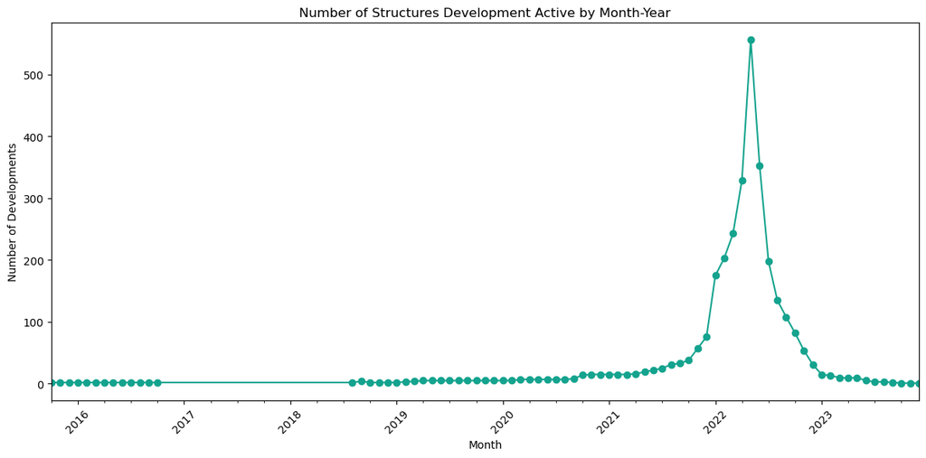

```python
# Create a new column 'month' for each construction
activities['start_month'] = activities['start_date'].dt.to_period('M')
activities['end_month'] = activities['end_date'].dt.to_period('M')

# Create a range of months for each construction
months_involved = activities.apply(lambda row: pd.period_range(row['start_month'], row['end_month'], freq='M'), axis=1)

# Flatten the list of months
months_involved = [month for sublist in months_involved for month in sublist]

# Count occurrences of each month
month_counts = pd.Series(months_involved).value_counts().sort_index()

# Plotting
plt.figure(figsize=(12, 6))

# Using pandas plot function to create a line chart
month_counts.plot(kind='line', marker='o', color=dark_theme_colors[1])

plt.title('Number of Structures Development Active by Month-Year')
plt.xlabel('Month')
plt.ylabel('Number of Developments')
plt.xticks(rotation=45)
plt.tight_layout()
plt.show()
```

#### Number of Developments each Classification

These numbers present the overall number of developments each classification. This should be used to help the city council have a quick view of what has been focused on expanding.

Among the developments' types, we can see that most developments are structures related:

- Structures 415
- Traffic Management 85
- Reserved Parking 69
- Event 17
- Public Event 14
- Private Event 1

```
Number of Developments for Each Classification:
Structures            415
Traffic Management     85
Reserved Parking       69
Event                  17
Public Event           14
Private Event           1
Name: classification, dtype: int64
```

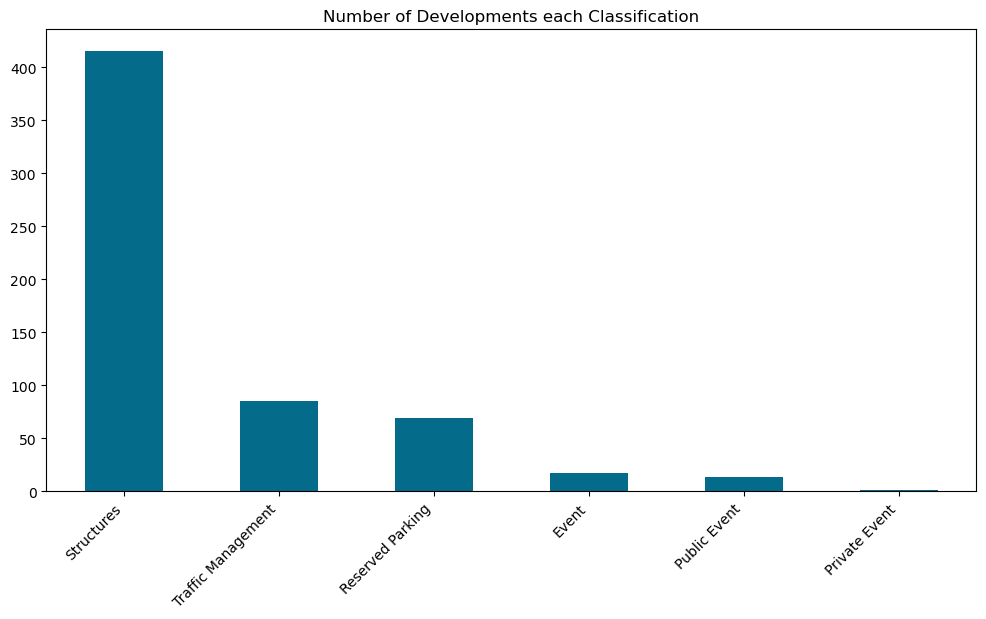

```python
# Use value_counts to get the count of each unique value
value_counts = activities['classification'].value_counts()

# Print the number of developments for each classification
print("Number of Developments for Each Classification:")
print(value_counts)

# Plotting
plt.figure(figsize=(12, 6))
value_counts.plot(kind='bar', color=dark_theme_colors[3])
plt.xlabel('')
plt.ylabel('')
plt.title('Number of Developments each Classification')
plt.xticks(rotation=45, ha='right')
plt.show()
```

#### Visualisation of Active Developments over Time

This map shows the active developments with a time bar running. By looking at the map, user can have an overview of the area focused each month.

- Each point represents an active development at the time.
- Each development has a color represented:
  - Structures: #08af64
  - Traffic Management: #14a38e
  - Event: #0f9295
  - Reserved Parking: #056b8a
  - Public #121212
  - Private Event: #121212

Mostly, the developments recorded were within Melbourne CBD. Especially in 2022, the number of structures outnumbered the other types of development.

```python
# Use geopy to get the coordinates for Melbourne
geolocator = Nominatim(user_agent="my_map")
location = geolocator.geocode("Melbourne, Australia")
melbourne_coords = (location.latitude, location.longitude)

# Filter data for Melbourne
activities = activities[(activities['latitude'].notna()) & (activities['longitude'].notna())]

# Create a new column 'month' for each construction
activities['start_month'] = activities['start_date'].dt.to_period('M')
activities['end_month'] = activities['end_date'].dt.to_period('M')

# Create a GeoJSON FeatureCollection
feature_collection = {
    'type': 'FeatureCollection',
    'features': []
}

# Create a color dictionary for each classification
classification_colors = {
    'Structures': '#08af64',
    'Traffic Management': '#14a38e',
    'Event': '#0f9295',
    'Reserved Parking': '#056b8a',
    'Public Event': '#121212',
    'Private Event': '#121212'
}

# Populate the FeatureCollection with features for each construction
for index, row in activities.iterrows():
    classification = row['classification']
    color = classification_colors.get(classification, 'gray')  # Default to gray if classification is not in the dictionary

    feature = {
        'type': 'Feature',
        'geometry': {
            'type': 'Point',
            'coordinates': [row['longitude'], row['latitude']]
        },
        'properties': {
            'time': row['start_month'].strftime('%Y-%m'),
            'popup': f"{row['start_month'].strftime('%Y-%m')}<br>{classification}",
            'icon': 'circle',
            'iconstyle': {
                'fillColor': color,
                'color': color,
                'fillOpacity': 1,
                'radius': 10
            }
        }
    }
    feature_collection['features'].append(feature)

# Create a Folium Map centered around Melbourne
melbourne_map = folium.Map(location=melbourne_coords, zoom_start=12)

# Add the time-indexed GeoJSON data to the map
plugins.TimestampedGeoJson(
    feature_collection,
    period='P1M',
    duration='P1M',
    auto_play=True,
    add_last_point=True,
    max_speed=1,
    loop=True
).add_to(melbourne_map)

# Display the map in the notebook
display(melbourne_map)
```

Make this Notebook Trusted to load map: File -> Trust Notebook

[interactive chart not shown]

#### Duration of Classification

Having duration of each type of development can help the council estimate the time and resource to finish.

Over years, we can conclude that "Event" development took most time to be completed, followed by "Traffic Management" and "Structures" developments. Event's durations varied, which can be harder to estimate.

```
       classification  duration
1       Private Event       0.0
2        Public Event       0.0
3    Reserved Parking       0.0
4          Structures      76.0
5  Traffic Management     171.0
0               Event     305.0
```

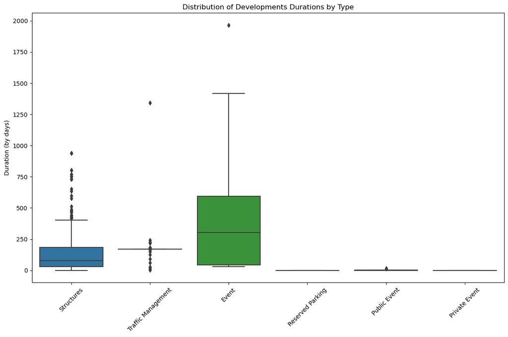

```python
# Group by 'classification', 'month_year' and calculate the average duration
average_duration_by_month_year = activities.groupby(['classification'])['duration'].median().reset_index()

# Sort the DataFrame by 'month_year'
sorted_average_duration = average_duration_by_month_year.sort_values(by='duration')

# Display the resulting DataFrame
print(sorted_average_duration)

# Plotting
plt.figure(figsize=(12, 8))

# Using seaborn to create a box plot
sns.boxplot(x='classification', y='duration', data=activities)

plt.title('Distribution of Developments Durations by Type')
plt.xlabel('')
plt.ylabel('Duration (by days)')
plt.xticks(rotation=45)
plt.tight_layout()
plt.show()
```

## Part 2.2: Structures Development Analysis

```python
activities_structures = activities[activities['classification'] == 'Structures']
```

#### Number of Active Structures Developement through Time

This chart helps the city council tracking the overall trend of specific structures developments over time.

The number of structures developments increased dramatically during 2022, due to the same reason with the overall constructions - post covid.

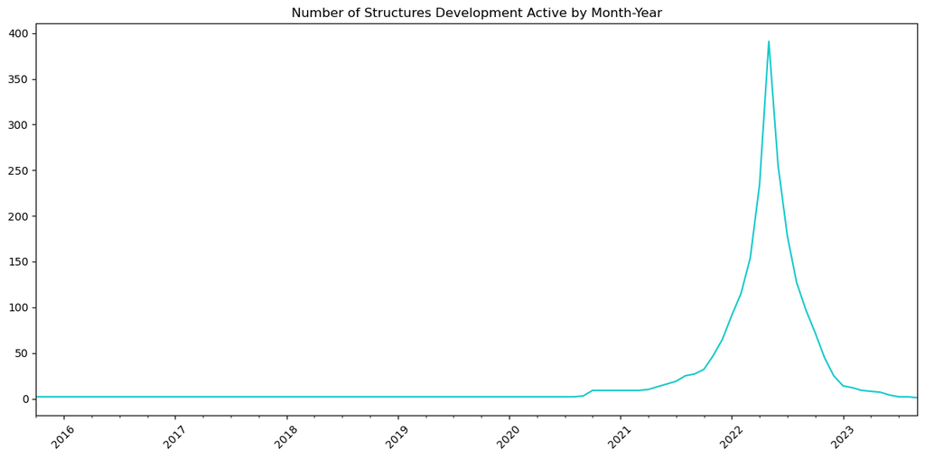

```python
# Create a new column 'month' for each construction
activities_structures['start_month'] = activities_structures['start_date'].dt.to_period('M')
activities_structures['end_month'] = activities_structures['end_date'].dt.to_period('M')

# Create a range of months for each construction
months_involved = activities_structures.apply(lambda row: pd.period_range(row['start_month'], row['end_month'], freq='M'), axis=1)

# Flatten the list of months
months_involved = [month for sublist in months_involved for month in sublist]

# Count occurrences of each month
month_counts = pd.Series(months_involved).value_counts().sort_index()

# Plotting
plt.figure(figsize=(12, 6))

# Using pandas plot function to create a line chart
month_counts.plot(kind='line', color=light_theme_colors[3])

plt.title('Number of Structures Development Active by Month-Year')
plt.xlabel('')
plt.ylabel('')
plt.xticks(rotation=45)
plt.tight_layout()
plt.show()
```

#### Number of Developments using each Land

This chart help the city council deciding on alternative solutions during each development, so that it will not affect on the citizens' daily lives.

Over the years, Car parks and Dwellings areas were most affected by structures development.

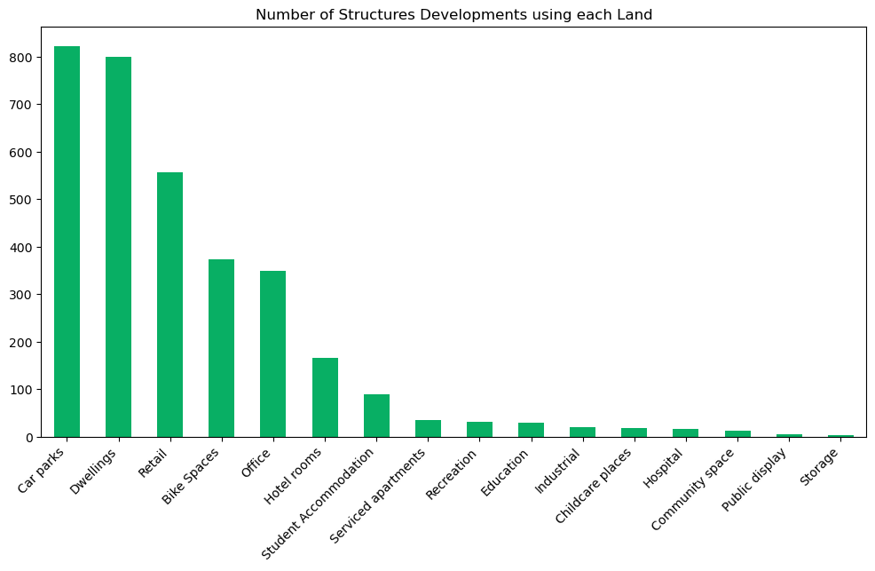

```python
df_melted = pd.melt(footprints, value_vars=['land_use_1', 'land_use_2', 'land_use_3'], var_name='land_use')

# Use value_counts to get the count of each unique value
value_counts = df_melted['value'].value_counts()

# Plotting
plt.figure(figsize=(12, 6))

# Plotting
value_counts.plot(kind='bar', color=dark_theme_colors[0])
plt.xlabel('')
plt.ylabel('')
plt.title('Number of Structures Developments using each Land')
plt.xticks(rotation=45, ha='right')
plt.show()
```

#### Number of Developments each Shape Type

This chart helps the city council to have an overview of the developments' shape types.

The shape of developments be considered in conjunction with their intended functionality. Certain shapes may be more suitable for residential areas, while others may be better suited for commercial or industrial zones.

It can be concluded here that mostly the developments have the shape of podium and tower, so they should be buildings or houses.

```
Number of Developments for Each Shape Type:
podium       650
tower        506
extension    102
Name: shape_type, dtype: int64
```

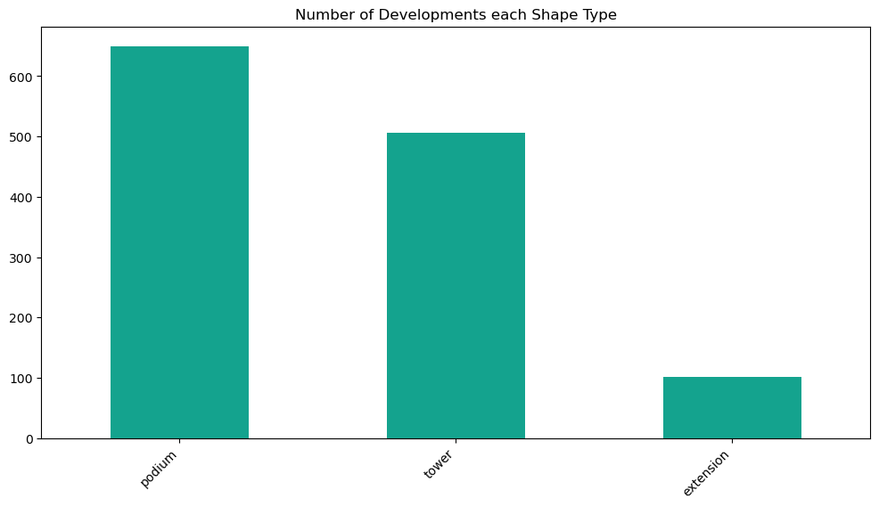

```python
# Use value_counts to get the count of each unique value
value_counts = footprints['shape_type'].value_counts()

# Print the number of developments for each classification
print("Number of Developments for Each Shape Type:")
print(value_counts)

# Plotting
plt.figure(figsize=(12, 6))
value_counts.plot(kind='bar', color=dark_theme_colors[1])
plt.xlabel('')
plt.ylabel('')
plt.title('Number of Developments each Shape Type')
plt.xticks(rotation=45, ha='right')
plt.show()
```